# EJERCICIO-3-EAM

Author

Eric Alvarado Meza

# Control de larvas de mosquitos

## 1.- Diseño experimental

Se va a evaluar el efecto de 2 pesticidas en la supervivivencia de las larvas del mosquito *Aedes aegipty*, de 3 zonas distintas con distintos niveles histroria/exposición a contaminantes, este último porque se sospecha que puede afectar a la respuesta de las larvas al pesticida. Siendo mas específicos se tomaran 100 adultos de cada cuerpo de agua, se llevaran al laboratorio y seran criados en condiciones homogeneas para obtener 50 larvas para exponerlas a cada pesticida.

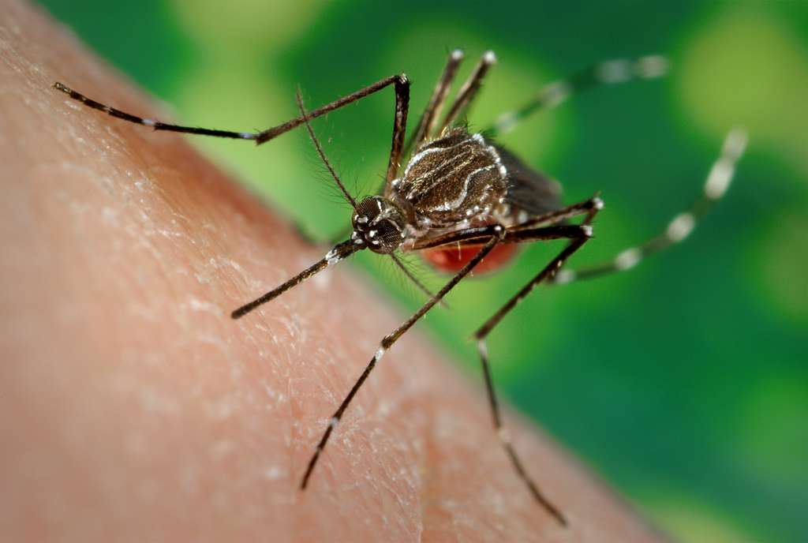

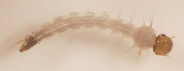

Debido al poco conocimiento que se tiene de la exposición previa a contaminantes de cada zona, esta se vuelve una variable no medible, es decir, actua como una variable aleatoria, sumado a esto en el diseño se aplicaran los tres tratamientos de pesticida a las larvas obtenidas de los adultos de cada zona, por lo cual podemos decir que **el diseño experimental corresponde a un modelo mixto.**

## 2.- Arreglo de los tratamientos

Como se mencionó anteriormente lo que se hara es tomar 100 adultos de cada zona para su posterior cria en condiciones homogenas, esto para obtener 50 larvas para exponer a cada pesticida y asi comparar la supervivencia de estas en cada caso.

Este experimento tiene dos varaiables que correponde al tratamiento y la zona:

- El tratamiento (T)
- La zona (Z)

Y cada variable tiene tres niveles:

- Niveles tratamiento: Control, Mezcla de *Bacillus thuringiensis*, *Beauveria bassiana*, *Peacelomyces fumorosae* (Pesticida A) y Temefos (Pesticida B)
- Niveles zona: Pristino, uso humano medio y muy alterado

No obstante es necesario aclarar que debido a la falta de detalles del territorio la variable se vuelve no medible y sus efectos en los tratamientos debe de ser considerados como aleatorios.

Por todo lo anteriormente mencionado podemos decir que **el arreglo de los tramientos corresponde a uno de 1 factor de multiples niveles (3) acompañado de una varaiable aleatoria también de multiples niveles (3).**

## 3.- Modelo del experimento

Debido a que se trata de un modelo mixto la ecuación que mejor representa al modelo del experimento es la siguiente:

$$y_{ijk} = \mu + T_{i} + \delta_{j(i)} + \epsilon_{k(ij)}$$

Donde:

y<sub>ijK</sub>= Porcentaje de supervivivencia

$\mu$= Media general

T<sub>i</sub>= El tratamiento de pesticida aplicado

$\delta_{k(j)}$= Es el efecto aleatorio del terirtorio en el pesticida

$\epsilon_{k(ij)}$= Es el error.

## 4.- Supuestos para el análisis estadístico

Los supuestos que se asumen para este analisis estadístico son:

- Normalidad: Lo que significa que nuestro valores siguen una distribucion normal.
- Independencia: Los datos observados de la supervivivencia son indepndientes uno de otro.
- Homocedasticidad: Esto significa que las varainzas seran similares o iguales entre si.
- Linealidad: Habra una relacion lineal en este caso entre el % de supervivencia y el tratamiento de pesticida aplicado.

## 5.- Criterio/nivel de significancia

El criterio de significancia establecido para este experiemnto sera de 0.05

## 6.- Exploración de datos

**Tabla general de datos**

DATOS MOSQUITOS

| Tratamiento | Territorio | Supervivencia |
| --- | --- | --- |
| Control | prístino | 77.2 |
| Pesticida_A | prístino | 58.8 |
| Pesticida_B | prístino | 57.8 |
| Control | uso humano medio | 80.4 |
| Pesticida_A | uso humano medio | 60.6 |
| Pesticida_B | uso humano medio | 58.6 |
| Control | muy alterado | 82.3 |
| Pesticida_A | muy alterado | 53.7 |
| Pesticida_B | muy alterado | 46.6 |

**Media, desviacion estandar y varianza**

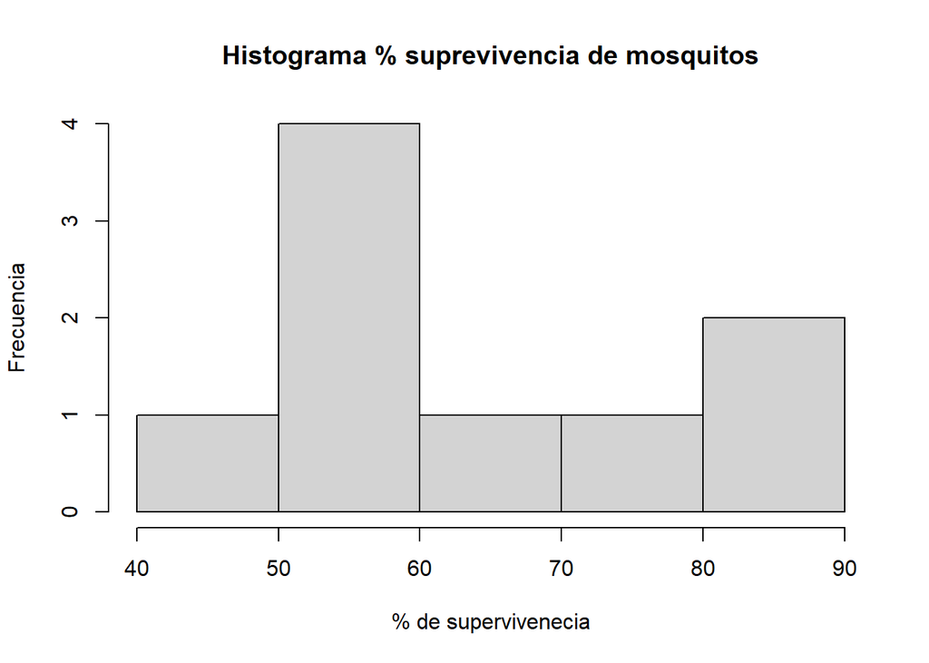

Exploracion estadistica por tratamiento

| Tratamiento | Media | Varianza | Desv_Estandar |
| --- | --- | --- | --- |
| Control | 79.96667 | 6.643333 | 2.577466 |
| Pesticida_A | 57.70000 | 12.810000 | 3.579106 |
| Pesticida_B | 54.33333 | 45.013333 | 6.709198 |

Exploracion estadistica por Territorio

| Territorio | Media | Varianza | Desv_Estandar |
| --- | --- | --- | --- |
| muy alterado | 60.86667 | 357.1433 | 18.89824 |
| prístino | 64.60000 | 119.3200 | 10.92337 |
| uso humano medio | 66.53333 | 145.2133 | 12.05045 |

## 7.- Construcción del modelo y minimo adecuado

**Modelo Completo**

```
Linear mixed-effects model fit by maximum likelihood
  Data: Datos_mosquitos
       AIC      BIC    logLik
  59.44556 60.43168 -24.72278

Random effects:
 Formula: ~1 | Territorio
        (Intercept) Residual
StdDev:    1.065277 3.631957

Fixed effects:  Supervivencia ~ Tratamiento
                           Value Std.Error DF   t-value p-value
(Intercept)             79.96667  2.676371  4 29.878765  0.0000
TratamientoPesticida_A -22.26667  3.631957  4 -6.130763  0.0036
TratamientoPesticida_B -25.63333  3.631957  4 -7.057720  0.0021
 Correlation:
                       (Intr) TrtP_A
TratamientoPesticida_A -0.679
TratamientoPesticida_B -0.679  0.500

Standardized Within-Group Residuals:
       Min         Q1        Med         Q3        Max
-1.9522685 -0.7956460  0.2689775  0.8194237  1.0316680

Number of Observations: 9
Number of Groups: 3
```

```
            numDF denDF  F-value p-value
(Intercept)     1     4 1480.878  <.0001
Tratamiento     2     4   29.419  0.0041
```

**Modelo nulo**

```
Linear mixed-effects model fit by maximum likelihood
  Data: Datos_mosquitos
       AIC    BIC    logLik
  76.24933 76.841 -35.12467

Random effects:
 Formula: ~1 | Territorio
         (Intercept) Residual
StdDev: 0.0003148247 11.98675

Fixed effects:  Supervivencia ~ 1
            Value Std.Error DF  t-value p-value
(Intercept)    64  4.237957  6 15.10162       0

Standardized Within-Group Residuals:
       Min         Q1        Med         Q3        Max
-1.4516026 -0.5172377 -0.4338123  1.1012157  1.5266855

Number of Observations: 9
Number of Groups: 3
```

```
            numDF denDF  F-value p-value
(Intercept)     1     6 228.0588  <.0001
```

**Comparación de modelos**

```
         Model df      AIC      BIC    logLik   Test  L.Ratio p-value
Modelo_1     1  5 59.44556 60.43168 -24.72278
Modelo_2     2  3 76.24933 76.84100 -35.12467 1 vs 2 20.80377  <.0001
```

Gracias a lo visto en la comparación de modelos podemos decir que el modelo mixto propuesto es el mejor para explicar los porcentajes de supervivencia.

## 8.- Valoracion del modelo y análisis de residuos

**Comparacion multiple**

```
              Model df      AIC      BIC    logLik   Test  L.Ratio p-value
ratas.lme.m4A     1  4 74.70958 75.49848 -33.35479
Modelo_1          2  5 59.44556 60.43168 -24.72278 1 vs 2 17.26402  <.0001
```

```
              Model df      AIC      BIC    logLik   Test  L.Ratio p-value
ratas.lme.m4B     1  4 76.91161 77.70050 -34.45580
Modelo_1          2  5 59.44556 60.43168 -24.72278 1 vs 2 19.46605  <.0001
```

```
              Model df      AIC      BIC    logLik   Test  L.Ratio p-value
ratas.lme.m4C     1  4 58.61309 59.40199 -25.30655
Modelo_1          2  5 59.44556 60.43168 -24.72278 1 vs 2 1.167537  0.2799
```

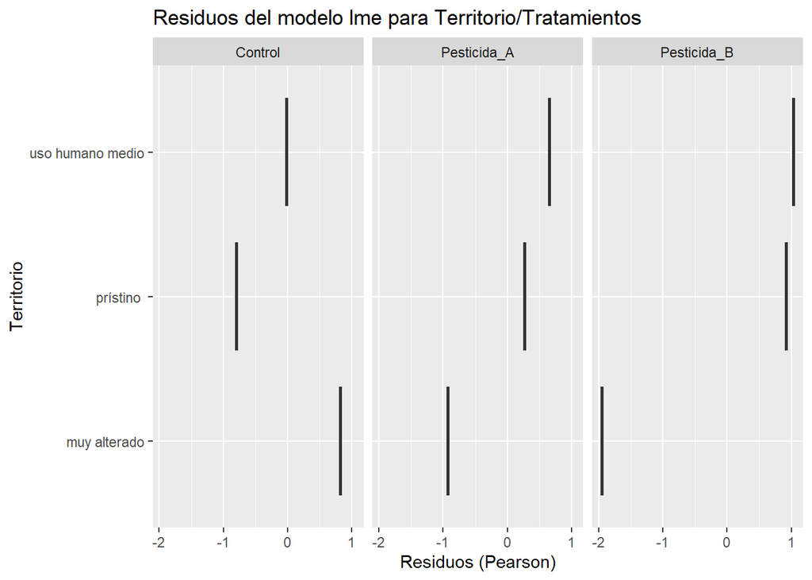

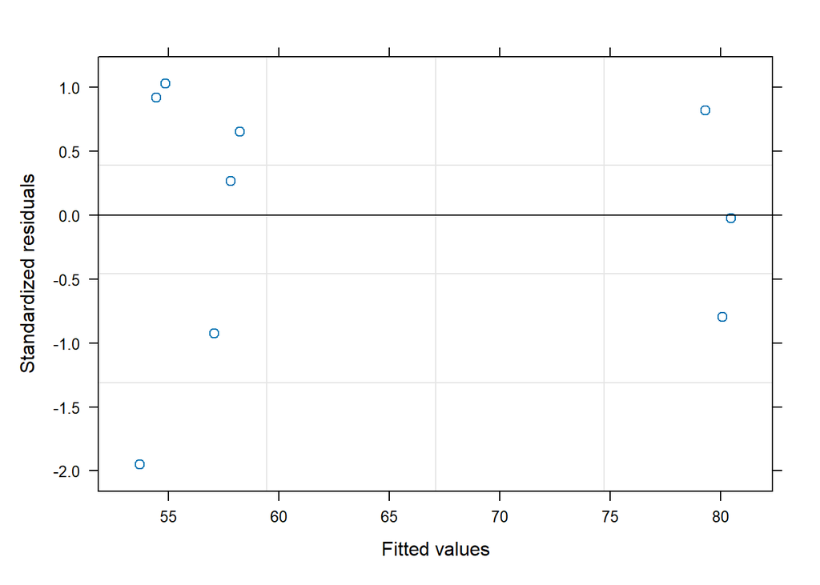

## 9 .- Diferencias entre tratamientos

De acuerdo con la información obtenida podemos ver que existe una diferencia significativa entre los dos pesticidas y el control, sin embargo, al momento de comparar los pesticidas no se observo una diferencia significativa entre uno y otro.